# 04 — The Rising Floor

# 4. Competitive Threshold Curves

What distance does a merely-median (or below-average) competitor have each year? For each year, we find the player sitting at the SG_total median and at the SG_total 25th percentile, and read off *that specific player’s* distance. Worth flagging upfront: extracting a single player’s value at an exact rank is a genuinely noisy way to measure this — unlike a group average, one long-hitting-but-otherwise-mediocre player landing exactly at the 25th percentile that year can swing the reading by many yards. Treat this section’s curves as illustrative, not as precise as the group-based metrics elsewhere in this notebook.

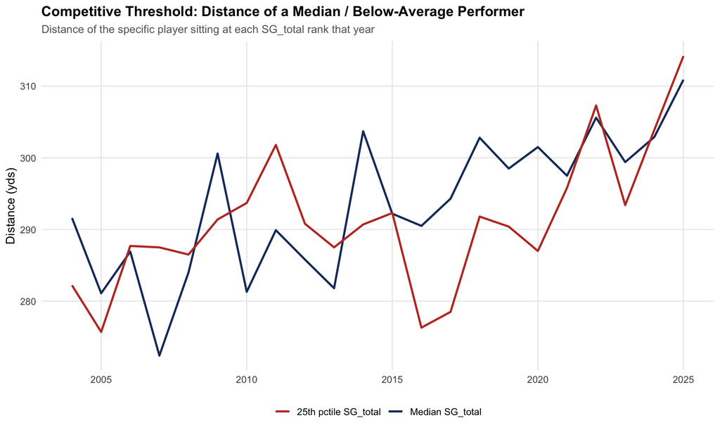

```r
threshold_by_year <- df_main %>%
  group_by(year) %>%
  arrange(sg_total, .by_group = TRUE) %>%
  summarise(
    n = n(),
    dist_at_median_sg = distance[ceiling(0.50 * n())],
    dist_at_p25_sg    = distance[ceiling(0.25 * n())],
    .groups = "drop"
  )

p_threshold <- ggplot(threshold_by_year, aes(year)) +
  geom_line(aes(y = dist_at_median_sg, color = "Median SG_total"), linewidth = 1) +
  geom_line(aes(y = dist_at_p25_sg, color = "25th pctile SG_total"), linewidth = 1) +
  scale_color_manual(values = c("Median SG_total" = COL_PRIMARY, "25th pctile SG_total" = COL_ACCENT), name = NULL) +
  labs(
    title    = "Competitive Threshold: Distance of a Median / Below-Average Performer",
    subtitle = "Distance of the specific player sitting at each SG_total rank that year",
    x = NULL, y = "Distance (yds)"
  ) +
  THEME_BASE

p_threshold
```

```r
thresh_2004 <- threshold_by_year %>% filter(year == min(year))
thresh_2025 <- threshold_by_year %>% filter(year == max(year))
gap <- threshold_by_year$dist_at_p25_sg - threshold_by_year$dist_at_median_sg
reversals <- sum(gap > 0)
```

# 5. Minimum Viable Analysis (“Extended Image 3”)

Even restricting to the *best* performers each year (top 25/50/100 by SG_total, speed era only), has the *minimum* power level within that elite group risen — not just the average?

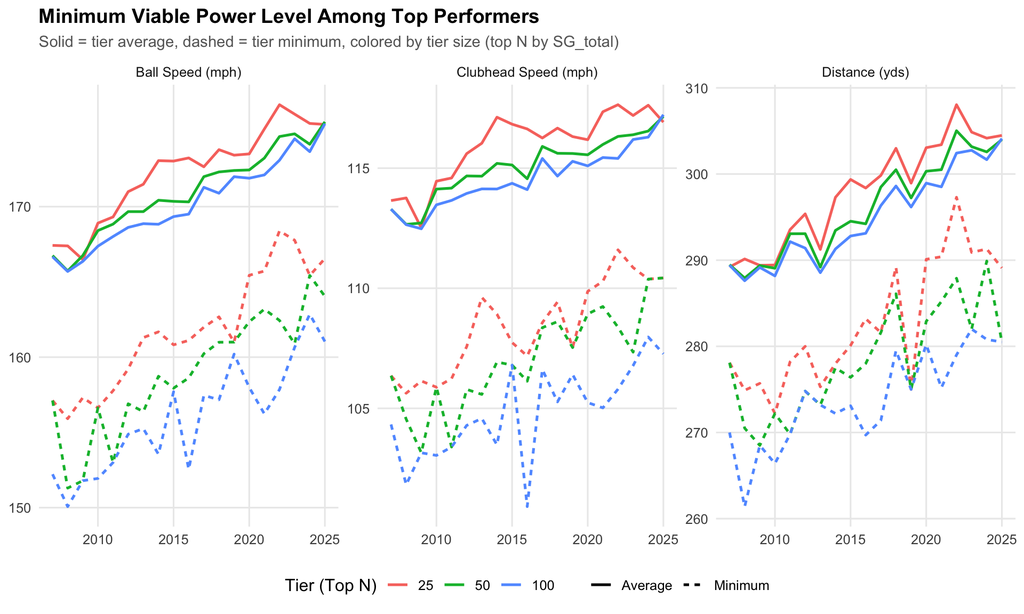

```r
tier_stats <- function(data, tier_n) {
  data %>%
    group_by(year) %>%
    arrange(desc(sg_total), .by_group = TRUE) %>%
    slice_head(n = tier_n) %>%
    summarise(
      avg_dist = mean(distance), min_dist = min(distance),
      avg_ball = mean(ball_speed), min_ball = min(ball_speed),
      avg_chs  = mean(chs), min_chs = min(chs),
      .groups = "drop"
    ) %>%
    mutate(tier = factor(tier_n, levels = c(25, 50, 100)))
}

tiers <- bind_rows(tier_stats(df_speed, 25), tier_stats(df_speed, 50), tier_stats(df_speed, 100))

tiers_long <- tiers %>%
  pivot_longer(c(avg_dist, min_dist, avg_ball, min_ball, avg_chs, min_chs), names_to = "stat", values_to = "value") %>%
  mutate(
    metric = case_when(str_detect(stat, "dist") ~ "distance", str_detect(stat, "ball") ~ "ball_speed", TRUE ~ "chs"),
    type   = if_else(str_detect(stat, "avg"), "Average", "Minimum")
  )

p_tiers <- ggplot(tiers_long, aes(year, value, color = tier, linetype = type)) +
  geom_line(linewidth = 0.9) +
  facet_wrap(~metric, scales = "free_y", labeller = as_labeller(metric_labels)) +
  labs(
    title    = "Minimum Viable Power Level Among Top Performers",
    subtitle = "Solid = tier average, dashed = tier minimum, colored by tier size (top N by SG_total)",
    x = NULL, y = NULL, color = "Tier (Top N)", linetype = NULL
  ) +
  THEME_BASE

p_tiers
```

```r
min_dist_25 <- tiers %>% filter(tier == 25)
min_dist_growth <- 100 * (min_dist_25$min_dist[min_dist_25$year == max(min_dist_25$year)] -
                            min_dist_25$min_dist[min_dist_25$year == min(min_dist_25$year)]) /
                            min_dist_25$min_dist[min_dist_25$year == min(min_dist_25$year)]
```

# 6. Time-to-Obsolescence

For each player: years from their strokes-gained-era entry (`sg_entry_year`) until the field’s 25th-percentile distance first exceeds their (fixed) entry-season distance (`dist_entry`). As flagged in the Overview, many players haven’t been overtaken within the observed data — they’re censored, not immune — so we compute an explicit `censored` flag alongside the time.

```r
field_p25 <- df_main %>% group_by(year) %>% summarise(p25 = quantile(distance, 0.25), .groups = "drop")
DATA_END_YEAR <- max(df_main$year)

players <- df_main %>% distinct(player_name, sg_entry_year, dist_entry, entry_cohort)

compute_obsolescence <- function(sg_entry_year, dist_entry) {
  candidate_years <- field_p25 %>% filter(year >= sg_entry_year, p25 > dist_entry) %>% arrange(year)
  if (nrow(candidate_years) == 0) {
    return(tibble(time_to_obsolescence = DATA_END_YEAR - sg_entry_year, censored = TRUE))
  }
  y <- candidate_years$year[1]
  tibble(time_to_obsolescence = y - sg_entry_year, censored = FALSE)
}

obsolescence <- players %>%
  mutate(res = pmap(list(sg_entry_year, dist_entry), compute_obsolescence)) %>%
  unnest(res) %>%
  mutate(event = as.integer(!censored))

censor_by_cohort <- obsolescence %>%
  group_by(entry_cohort) %>%
  summarise(n = n(), pct_censored = round(mean(censored) * 100, 1), .groups = "drop")

censor_by_cohort %>% print()
```

```
## # A tibble: 4 × 3
##   entry_cohort     n pct_censored
##   <fct>        <int>        <dbl>
## 1 pre-2000       149          8.1
## 2 2000–2009      232         16.8
## 3 2010–2019      248         27.8
## 4 2020+          164         74.4
```

**Finding:** censoring ranges from 8.1% (pre-2000 entrants, decades of follow-up) to 74.4% (2020+ entrants, barely any follow-up yet) — confirms the concern from the Overview. Any comparison across cohorts needs to account for this rather than silently dropping the censored majority in the newest cohort.

## 6.1 Violin of observed times (as the docs ask for) — with censoring shown

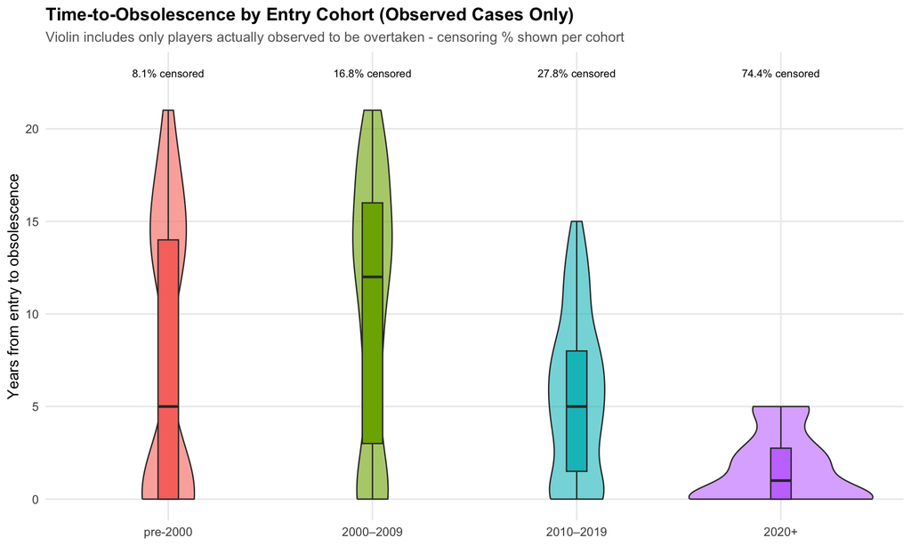

```r
max_time <- max(obsolescence$time_to_obsolescence)

p_violin <- ggplot(obsolescence %>% filter(!censored), aes(entry_cohort, time_to_obsolescence, fill = entry_cohort)) +
  geom_violin(alpha = 0.6) +
  geom_boxplot(width = 0.1, outlier.shape = NA) +
  geom_text(
    data = censor_by_cohort, inherit.aes = FALSE,
    aes(x = entry_cohort, y = max_time + 2, label = paste0(pct_censored, "% censored")),
    size = 3
  ) +
  labs(
    title    = "Time-to-Obsolescence by Entry Cohort (Observed Cases Only)",
    subtitle = "Violin includes only players actually observed to be overtaken - censoring % shown per cohort",
    x = NULL, y = "Years from entry to obsolescence"
  ) +
  THEME_BASE +
  theme(legend.position = "none")

p_violin
```

## 6.2 Kaplan-Meier: the censoring-aware summary

```r
obsolescence_km <- obsolescence %>% filter(entry_cohort != "2020+")

fit_km <- survfit(Surv(time_to_obsolescence, event) ~ entry_cohort, data = obsolescence_km)
print(fit_km)
```

```
## Call: survfit(formula = Surv(time_to_obsolescence, event) ~ entry_cohort,
##     data = obsolescence_km)
##
##                          n events median 0.95LCL 0.95UCL
## entry_cohort=pre-2000  149    137     11       2      14
## entry_cohort=2000–2009 232    193     14      13      14
## entry_cohort=2010–2019 248    179      8       7       9
```

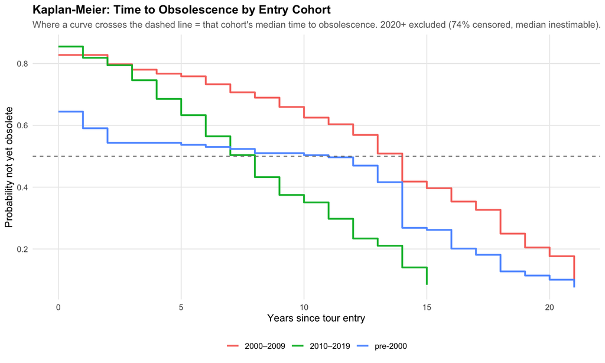

```r
km_tidy <- tidy(fit_km) %>% mutate(entry_cohort = str_remove(strata, "entry_cohort="))

p_km <- ggplot(km_tidy, aes(time, estimate, color = entry_cohort)) +
  geom_step(linewidth = 1) +
  geom_hline(yintercept = 0.5, linetype = "dashed", color = "grey50") +
  labs(
    title    = "Kaplan-Meier: Time to Obsolescence by Entry Cohort",
    subtitle = "Where a curve crosses the dashed line = that cohort's median time to obsolescence. 2020+ excluded (74% censored, median inestimable).",
    x = "Years since tour entry", y = "Probability not yet obsolete", color = NULL
  ) +
  THEME_BASE

p_km
```

```r
km_medians <- summary(fit_km)$table[, "median"]
```

**Finding:** 2020+ is excluded from this comparison — at 74.4% censored, the Kaplan-Meier curve never reaches the 50% mark, so its median isn’t estimable, not just imprecise. Among the three cohorts with adequate follow-up, the median time-to-obsolescence is **non-monotonic**: pre-2000 entrants took 11 years, 2000s entrants took the *longest* at 14 years, and 2010s entrants took the *shortest* at only 8 years. This tracks the era each cohort entered in rather than anything about the players themselves: 2000s entrants likely rode the post-Pro V1/COR-MOI distance boost (Project 1) for longer before the field caught up, while 2010s entrants ran into the field’s accelerating, faster-rising floor (Projects 1-2’s “Power Era”) sooner.

# 7. Summary